# HW_04

MINSI SUNG

06/10/2019

# Exercise 1: Univariate Data Reshaping

### Choose *EITHER* “Univariate Option 1” or “Univariate Option 2”. Both of these problems have three components:

### 1. Putting data in wider format;

### 2. Producing a plot of the wide data

### 3. Re-lengthening the wider data

### You are expected to use pivot_wider() and pivot_longer() for reshaping, and ggplot2 for the plot.

### Regarding the plot:

### Don’t worry about plotting all of the data from the wide tibble．

### The plot should be something that someone might actually want to produce in an analysis.

# Univariate Option 1

### 1. Make a tibble with one row per year, and columns for life expectancy for two or more countries.

Here I choose Japan and Taiwan to make the tibble. The column I would like to keep is “year” so id_cols = year. The new column names are coming from country and the values are from lifeExp

```r
Ex1_Op1<-gapminder %>%
  select(country,year,lifeExp) %>%
  filter(country %in% c("Taiwan","Japan")) %>%
  pivot_wider(id_cols = year,
              names_from = country,
              values_from = lifeExp)
DT::datatable(Ex1_Op1)
```

|  | year | Japan | Taiwan |
| --- | --- | --- | --- |
| 1 | 1952 | 63.03 | 58.5 |
| 2 | 1957 | 65.5 | 62.4 |
| 3 | 1962 | 68.73 | 65.2 |
| 4 | 1967 | 71.43 | 67.5 |
| 5 | 1972 | 73.42 | 69.39 |
| 6 | 1977 | 75.38 | 70.59 |
| 7 | 1982 | 77.11 | 72.16 |
| 8 | 1987 | 78.67 | 73.4 |
| 9 | 1992 | 79.36 | 74.26 |
| 10 | 1997 | 80.69 | 75.25 |

[output cut: 2 more lines]

### 2. Take advantage of this new data shape to scatterplot life expectancy for one country against that of another.

The red dots represent the life expectancy of Japan for each year and black dots are for Taiwan

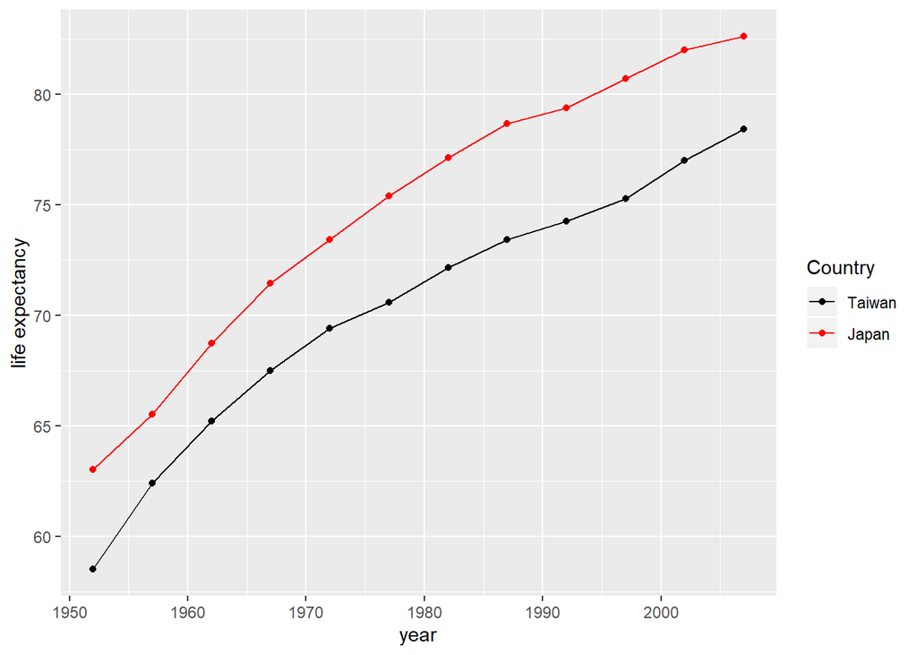

```r
Ex1_Op1 %>%
  ggplot()+
  geom_point(aes(x = year,y = Japan, colour = "red"))+
  geom_line(aes(x = year,y = Japan, colour = "red"))+
  geom_point(aes(x = year,y = Taiwan, colour = "black"))+
  geom_line(aes(x = year,y = Taiwan, colour = "black"))+
  labs(y= "life expectancy")+
  scale_color_manual(name = "Country",
                     values = c( "black" = 'black','red' = 'red'),
                     labels = c('Taiwan', 'Japan'))
```

From the plot above, we can see that the life expectancy of both Japan and Taiwan are growing with the similar speed.

### 3. Re-lengthen the data.

To re=lengthen the data, we need to use pivot_longer. The columns that I want to turn into a single colunm are Japan and Taiwan, so I use -year. The name of the new column is “country” and the name for the value is “lifeExp”

```r
EX1_Op1_2<- Ex1_Op1 %>%
  pivot_longer(cols = -year,
               names_to  = "country",
               values_to = "lifeExp")

DT::datatable(EX1_Op1_2)
```

|  | year | country | lifeExp |
| --- | --- | --- | --- |
| 1 | 1952 | Japan | 63.03 |
| 2 | 1952 | Taiwan | 58.5 |
| 3 | 1957 | Japan | 65.5 |
| 4 | 1957 | Taiwan | 62.4 |
| 5 | 1962 | Japan | 68.73 |
| 6 | 1962 | Taiwan | 65.2 |
| 7 | 1967 | Japan | 71.43 |
| 8 | 1967 | Taiwan | 67.5 |
| 9 | 1972 | Japan | 73.42 |
| 10 | 1972 | Taiwan | 69.39 |

[output cut: 14 more lines]

# Exercise 2: Multivariate Data Reshaping

### Choose *EITHER* “Multivariate Option 1” or “Multivariate Option 2”. All of these problems have two components:

### 1. Putting data in wider format;

### 2. Re-lengthening the data

### Don’t worry about producing a plot here. You are expected to use pivot_wider() and pivot_longer() for reshaping.

# Multivariate Option 1

### 1. Make a tibble with one row per year, and columns for life expectancy and GDP per capita (or two other numeric variables) for two or more countries.

Again, here I choose Taiwan and Japan for this exercise. To make a tibble with columns for lifeExp and gdpPerCap for two countries, I need to use pivot_wider. The colunmn I would like to keep is year and the the colunm that contains the part of the variable is country. Here I use underscroll as my separator and the values are from lifeExp and gdpPercap.

```r
Ex2_Op1<-gapminder %>%
  filter(country %in% c("Taiwan","Japan")) %>%
  select(year,country,lifeExp,gdpPercap) %>%
  pivot_wider(id_cols = year,
              names_from = country,
              names_sep = "_",
              values_from = c(lifeExp,gdpPercap))
DT::datatable(Ex2_Op1)
```

|  | year | lifeExp_Japan | lifeExp_Taiwan | gdpPercap_Japan | gdpPercap_Taiwan |
| --- | --- | --- | --- | --- | --- |
| 1 | 1952 | 63.03 | 58.5 | 3216.956347 | 1206.947913 |
| 2 | 1957 | 65.5 | 62.4 | 4317.694365 | 1507.86129 |
| 3 | 1962 | 68.73 | 65.2 | 6576.649461 | 1822.879028 |
| 4 | 1967 | 71.43 | 67.5 | 9847.788607 | 2643.858681 |
| 5 | 1972 | 73.42 | 69.39 | 14778.78636 | 4062.523897 |
| 6 | 1977 | 75.38 | 70.59 | 16610.37701 | 5596.519826 |
| 7 | 1982 | 77.11 | 72.16 | 19384.10571 | 7426.354774 |
| 8 | 1987 | 78.67 | 73.4 | 22375.94189 | 11054.56175 |
| 9 | 1992 | 79.36 | 74.26 | 26824.89511 | 15215.6579 |
| 10 | 1997 | 80.69 | 75.25 | 28816.58499 | 20206.82098 |

[output cut: 2 more lines]

### 2. Re-lengthen the data.

To re-lengthen the data I created above, just use pivot_longer then we can achieve the goal.

```r
Ex2_Op1_2<- Ex2_Op1 %>%
  pivot_longer(cols      = -year,
               names_to  = c(".value", "country"),
               names_sep = "_")
DT::datatable(Ex2_Op1_2)
```

|  | year | country | lifeExp | gdpPercap |
| --- | --- | --- | --- | --- |
| 1 | 1952 | Japan | 63.03 | 3216.956347 |
| 2 | 1952 | Taiwan | 58.5 | 1206.947913 |
| 3 | 1957 | Japan | 65.5 | 4317.694365 |
| 4 | 1957 | Taiwan | 62.4 | 1507.86129 |
| 5 | 1962 | Japan | 68.73 | 6576.649461 |
| 6 | 1962 | Taiwan | 65.2 | 1822.879028 |
| 7 | 1967 | Japan | 71.43 | 9847.788607 |
| 8 | 1967 | Taiwan | 67.5 | 2643.858681 |
| 9 | 1972 | Japan | 73.42 | 14778.78636 |
| 10 | 1972 | Taiwan | 69.39 | 4062.523897 |

[output cut: 14 more lines]

# Exercise 3: Table Joins

### Do *ALL* of the activities in this section.

Read in the made-up wedding guestlist and email addresses using the following lines (go ahead and copy-paste these):

```r
guest <- read_csv("https://raw.githubusercontent.com/STAT545-UBC/Classroom/master/data/wedding/attend.csv")
email <- read_csv("https://raw.githubusercontent.com/STAT545-UBC/Classroom/master/data/wedding/emails.csv")
```

Then, complete the following tasks using the tidyverse (tidyr, dplyr, …). No need to do any pivoting – feel free to leave guest in its current format.

## 3.1 For each guest in the guestlist (guest tibble), add a column for email address, which can be found in the email tibble.

First I need to create a new tibble to have all guests name match with their email. Then rename the guest to name for the following usage.

```r
email_Ex3<-email %>%
  separate_rows(guest, sep = ", ") %>%
  rename(name = guest)
DT::datatable(email_Ex3)
```

|  | name | email |
| --- | --- | --- |
| 1 | Sommer Medrano | sommm@gmail.com |
| 2 | Phillip Medrano | sommm@gmail.com |
| 3 | Blanka Medrano | sommm@gmail.com |
| 4 | Emaan Medrano | sommm@gmail.com |
| 5 | Blair Park | bpark@gmail.com |
| 6 | Nigel Webb | bpark@gmail.com |
| 7 | Sinead English | singlish@hotmail.ca |
| 8 | Ayra Marks | marksa42@gmail.com |
| 9 | Jolene Welsh | jw1987@hotmail.com |
| 10 | Hayley Booker | jw1987@hotmail.com |

[output cut: 18 more lines]

```r
email_Ex3 %>%
  inner_join(guest, by="name")
```

```
## # A tibble: 25 x 8
##    name  email party meal_wedding meal_brunch attendance_wedd~
##    <chr> <chr> <dbl> <chr>        <chr>       <chr>
##  1 Somm~ somm~     1 PENDING      PENDING     PENDING
##  2 Phil~ somm~     1 vegetarian   Menu C      CONFIRMED
##  3 Blan~ somm~     1 chicken      Menu A      CONFIRMED
##  4 Emaa~ somm~     1 PENDING      PENDING     PENDING
##  5 Blai~ bpar~     2 chicken      Menu C      CONFIRMED
##  6 Nige~ bpar~     2 <NA>         <NA>        CANCELLED
##  7 Sine~ sing~     3 PENDING      PENDING     PENDING
##  8 Ayra~ mark~     4 vegetarian   Menu B      PENDING
##  9 Jole~ jw19~     6 <NA>         <NA>        CANCELLED
## 10 Hayl~ jw19~     6 vegetarian   Menu C      CONFIRMED
## # ... with 15 more rows, and 2 more variables: attendance_brunch <chr>,
## #   attendance_golf <chr>
```

## 3.2Who do we have emails for, yet are not on the guestlist?

Anti_join drops all observations in first tibble that have a match in the second tibble. So we can use it to find who do we have emails but are not on the guestlist.

```r
email_Ex3_2<-email_Ex3 %>%
  anti_join(guest, by="name")

DT::datatable(email_Ex3_2)
```

|  | name | email |
| --- | --- | --- |
| 1 | Turner Jones | tjjones12@hotmail.ca |
| 2 | Albert Marshall | themarshallfamily1234@gmail.com |
| 3 | Vivian Marshall | themarshallfamily1234@gmail.com |

## 3.3 Make a guestlist that includes everyone we have emails for (in addition to those on the original guestlist).

Full_join combine both tibbles for all the data no matter whether the data is in both tibbles or not.

```r
email_Ex3_3<-guest %>%
  full_join(email_Ex3, by="name")

DT::datatable(email_Ex3_3)
```

|  | party | name | meal_wedding | meal_brunch | attendance_wedding | attendance_brunch | attendance_golf | email |
| --- | --- | --- | --- | --- | --- | --- | --- | --- |
| 1 | 1 | Sommer Medrano | PENDING | PENDING | PENDING | PENDING | PENDING | sommm@gmail.com |
| 2 | 1 | Phillip Medrano | vegetarian | Menu C | CONFIRMED | CONFIRMED | CONFIRMED | sommm@gmail.com |
| 3 | 1 | Blanka Medrano | chicken | Menu A | CONFIRMED | CONFIRMED | CONFIRMED | sommm@gmail.com |
| 4 | 1 | Emaan Medrano | PENDING | PENDING | PENDING | PENDING | PENDING | sommm@gmail.com |
| 5 | 2 | Blair Park | chicken | Menu C | CONFIRMED | CONFIRMED | CONFIRMED | bpark@gmail.com |
| 6 | 2 | Nigel Webb |  |  | CANCELLED | CANCELLED | CANCELLED | bpark@gmail.com |
| 7 | 3 | Sinead English | PENDING | PENDING | PENDING | PENDING | PENDING | singlish@hotmail.ca |
| 8 | 4 | Ayra Marks | vegetarian | Menu B | PENDING | PENDING | PENDING | marksa42@gmail.com |
| 9 | 5 | Atlanta Connolly | PENDING | PENDING | PENDING | PENDING | PENDING |  |
| 10 | 5 | Denzel Connolly | fish | Menu B | CONFIRMED | CONFIRMED | CONFIRMED |  |

[output cut: 23 more lines]